# Análisis de la Depresión Estudiantil

## Visualización de Scores

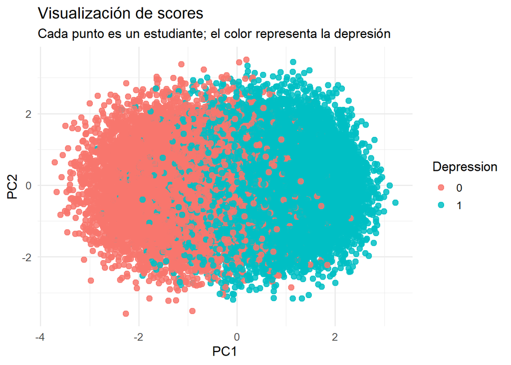

```r
scores_pca <- as.data.frame(pca$x)
scores_pca$Depression <- data_num$Depression

g_scores <- ggplot(scores_pca, aes(PC1, PC2, color = Depression)) +
  geom_point(size = 2.5, alpha = 0.85) +
  labs(
    title = "Visualización de scores",
    subtitle = "Cada punto es un estudiante; el color representa la depresión",
    x = "PC1",
    y = "PC2",
    color = "Depression"
  ) +
  theme_minimal(base_size = 13)

g_scores
```

## Visualización de Loadings

```r
loadings_pca <- as.data.frame(pca$rotation)
loadings_pca$Variable <- rownames(pca$rotation)

loadings_pca
```

|  | PC1 | PC2 | PC3 | PC4 | PC5 | PC6 | PC7 | PC8 | PC9 | PC10 | Variable |
| --- | --- | --- | --- | --- | --- | --- | --- | --- | --- | --- | --- |
| Age | -0.26335738 | -0.404922446 | -0.12283398 | -0.05504046 | -0.37020298 | -0.189156890 | -0.610848691 | -0.44483415 | 0.01379715 | 0.06729478 | Age |
| Academic.Pressure | 0.48921370 | -0.063134067 | -0.09775458 | -0.04836955 | -0.19060604 | -0.145868935 | 0.036114128 | -0.13296524 | -0.58233848 | -0.57365319 | Academic.Pressure |
| CGPA | 0.01017755 | -0.513223946 | 0.54633080 | 0.25531520 | 0.51523775 | 0.211577669 | -0.072966680 | -0.15643922 | -0.16447542 | -0.07582757 | CGPA |
| Study.Satisfaction | -0.23339933 | 0.500143854 | -0.28435058 | -0.05558817 | 0.45093943 | 0.294338623 | -0.218316173 | -0.45221977 | -0.25078996 | -0.07996069 | Study.Satisfaction |
| Work.Study.Hours | 0.27577823 | -0.159250259 | -0.21650355 | -0.09896473 | -0.12281723 | 0.757763357 | -0.360737220 | 0.32204524 | 0.11749694 | -0.07055875 | Work.Study.Hours |
| Sleep_Num | -0.09489078 | 0.416864502 | 0.49960420 | 0.43202634 | -0.51667715 | 0.258358778 | -0.088121696 | -0.07154346 | -0.17857154 | 0.04992383 | Sleep_Num |
| Diet_Num | -0.26994506 | -0.303899181 | -0.17857099 | -0.08831056 | -0.26709419 | 0.405846015 | 0.654019172 | -0.34833972 | -0.09099491 | 0.04094622 | Diet_Num |
| Financial.Stress | 0.43164264 | 0.124932519 | 0.13193865 | 0.01199061 | -0.01450904 | 0.038374185 | 0.072202132 | -0.52417380 | 0.66883730 | -0.22699598 | Financial.Stress |
| Suicidal_Num | 0.53676699 | 0.001448027 | -0.04010053 | -0.04329431 | 0.01988834 | 0.001880677 | 0.009468183 | -0.22432187 | -0.25301788 | 0.77043467 | Suicidal_Num |
| Family_History_Num | 0.06611820 | -0.106806404 | -0.49863981 | 0.84858549 | 0.06179053 | -0.066331925 | 0.040409294 | 0.01470553 | 0.07354582 | 0.00237296 | Family_History_Num |

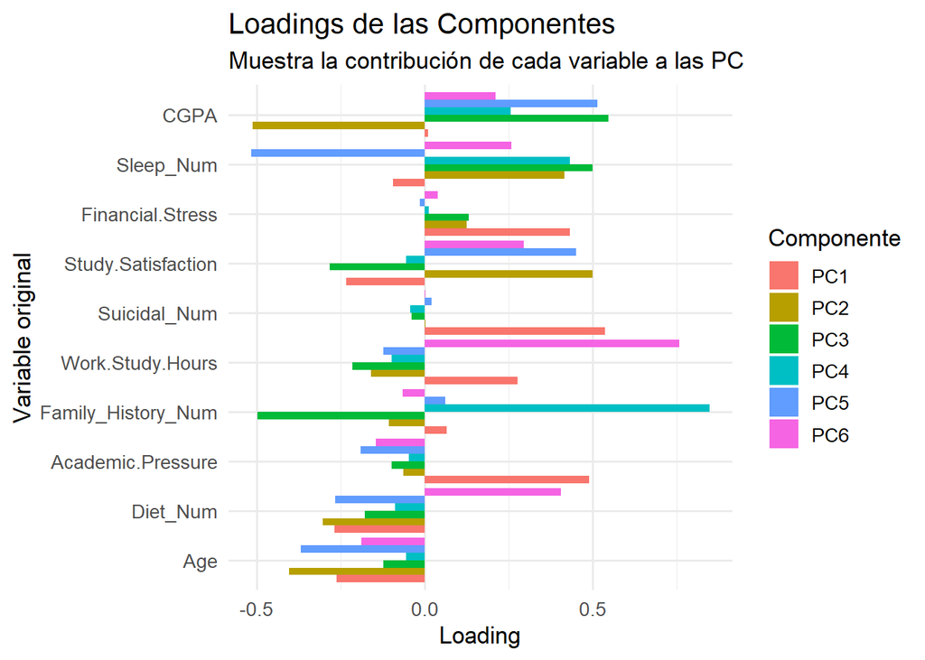

```r
loadings_long <- loadings_pca %>%
  tidyr::pivot_longer(
    cols = starts_with("PC"),
    names_to = "Componente",
    values_to = "Loading"
  )

ggplot(loadings_long %>% filter(Componente %in% c("PC1", "PC2", "PC3", "PC4", "PC5", "PC6")),
       aes(x = reorder(Variable, Loading), y = Loading, fill = Componente)) +
  geom_col(position = "dodge") +
  coord_flip() +
  labs(
    title = "Loadings de las Componentes",
    subtitle = "Muestra la contribución de cada variable a las PC",
    x = "Variable original",
    y = "Loading"
  ) +
  theme_minimal(base_size = 13)
```

PC1: Este primer componente define el núcleo de la vulnerabilidad psicológica. Demuestra de forma matemática que suicidal_num, la presión por los estudios y el estrés económico se mueven juntos en la misma dirección.

PC2: El signo opuesto entre el rendimiento académico y el bienestar indica que los estudiantes con altas calificaciones (CGPA hacia el negativo) experimentan un impacto directo que reduce drásticamente sus horas de sueño y la satisfacción con su carrera.

PC3: Muestra un grupo de estudiantes con calificaciones sobresalientes y buen sueño, pero que se desmarcan y se oponen a la variable de antecedentes familiares, sugiriendo un esfuerzo académico individual y desconectado de su contexto del hogar.

PC4: Al tener una carga tan masiva y dominante en la historia familiar, este componente representa la vulnerabilidad heredada o preexistente. Separa las crisis del día a día universitario (exámenes o dinero) y aísla el peso que representa para el estudiante que podria arrastrar antecedentes psiquiátricos desde su hogar.

PC5: Muestra un perfil donde el esfuerzo por mantener notas altas y estar satisfecho con la carrera choca de frente con una pérdida severa de las horas de sueño, marcando un patrón de autoexigencia extrema a costa del descanso básico.

PC6: Concluye que jornadas extensas de estudio y trabajo desestabilizan y transforman directamente los hábitos más básicos del estudiante representando el desgaste por rutina o burnout físico.

# Parte 11: MANOVA

## Definición de Grupos

Para evaluar el impacto de la salud mental en el entorno del estudiante, se definen dos grupos mutuamente excluyentes basados en la variable objetivo del estudio: * **Grupo 0 (Control):** Estudiantes que no reportan diagnóstico ni sintomatología depresiva. * **Grupo 1 (Casos):** Estudiantes con diagnóstico de depresión.

## Formulación de Hipótesis Estadísticas

Planteamos las siguientes hipótesis de investigación:

- **Hipótesis Nula ($H_0$):** $\boldsymbol{\mu}_{\text{Sin Depresión}} = \boldsymbol{\mu}_{\text{Con Depresión}}$
  - *Interpretación:* El vector de medias combinadas es idéntico entre estudiantes con y sin depresión. La salud mental no genera diferencias en el perfil multivariado de estas variables.
- **Hipótesis Alternativa ($H_1$):** $\boldsymbol{\mu}_{\text{Sin Depresión}} \neq \boldsymbol{\mu}_{\text{Con Depresión}}$
  - *Interpretación:* Existe una diferencia significativa en al menos una de las variables continuas al contrastar ambos grupos. Los centros de gravedad (centroides) de las nubes de datos están separados en el espacio multidimensional.

## Ejecución del Modelo y Contraste de Wilks’ Lambda

A continuación, se ajusta el modelo multivariado en R y se extrae específicamente el estadístico **Lambda de Wilks** para verificar la significancia del modelo global.

```r
variables_dependientes <- cbind(
  data_num$Age,
  data_num$Academic.Pressure,
  data_num$CGPA,
  data_num$Study.Satisfaction,
  data_num$Work.Study.Hours,
  data_num$Sleep_Num,
  data_num$Diet_Num,
  data_num$Financial.Stress,
  data_num$Suicidal_Num,
  data_num$Family_History_Num
)

# Les ponemos nombres para que la salida sea fácil de leer
colnames(variables_dependientes) <- c("Age", "Academic.Pressure", "CGPA",
                                      "Study.Satisfaction", "Work.Study.Hours",
                                      "Sleep_Num", "Diet_Num", "Financial.Stress",
                                      "Suicidal_Num", "Family_History_Num")

# Ajustamos el modelo MANOVA basado en el factor Depression
modelo_manova <- manova(variables_dependientes ~ Depression, data = data_num)

# Extraemos el resumen utilizando estrictamente la aproximación de Wilks
cat("--- RESULTADOS GLOBAL MANOVA (WILKS' LAMBDA) ---\n")
```

```
## --- RESULTADOS GLOBAL MANOVA (WILKS' LAMBDA) ---
```

```r
summary(modelo_manova, test = "Wilks")
```

```
##               Df   Wilks approx F num Df den Df    Pr(>F)
## Depression     1 0.48315   2980.1     10  27857 < 2.2e-16 ***
## Residuals  27866
## ---
## Signif. codes:  0 '***' 0.001 '**' 0.01 '*' 0.05 '.' 0.1 ' ' 1
```

A partir de la salida del modelo MANOVA, se puede evidenciar lo siguiente:

1. El valor Wilks’ $\boldsymbol{\lambda}$ es de 0.48315. Este valor oscila entre 0 y 1, donde 1 indicaría que los grupos son idénticos y 0 que están completamente separados. Un valor de 0.48315 revela que existe una separación multivariada sustancial entre los grupos. En términos prácticos, significa que aproximadamente el 52% (1 - 0.48315) de la varianza general de este conjunto de variables (su centroide) está fuertemente determinada por la presencia o ausencia de depresión.
2. Con un p-valor tan por debajo del umbral estándar ($\alpha = 0.05$), se rechaza contundentemente la Hipótesis Nula ($H_0$).

Con base en los valores encontrados se puede afirmar que el perfil completo del estudiante difiere significativamente dependiendo de si padece o no depresión.

Al haberse comprobado que existe una diferencia global real, se justifica metodológicamente el paso hacia los Análisis Posteriores (ANOVAs individuales) para desglosar este impacto variable por variable.

```r
summary.aov(modelo_manova)
```

```
##  Response Age :
##                Df Sum Sq Mean Sq F value    Pr(>F)
## Depression      1  34501   34501  1511.3 < 2.2e-16 ***
## Residuals   27866 636148      23
## ---
## Signif. codes:  0 '***' 0.001 '**' 0.01 '*' 0.05 '.' 0.1 ' ' 1
##
##  Response Academic.Pressure :
##                Df Sum Sq Mean Sq F value    Pr(>F)
## Depression      1  11994 11994.2  8112.4 < 2.2e-16 ***
## Residuals   27866  41200     1.5
## ---
## Signif. codes:  0 '***' 0.001 '**' 0.01 '*' 0.05 '.' 0.1 ' ' 1
##
##  Response CGPA :
##                Df Sum Sq Mean Sq F value   Pr(>F)
## Depression      1     29 28.8761  13.357 0.000258 ***
## Residuals   27866  60243  2.1619
## ---
## Signif. codes:  0 '***' 0.001 '**' 0.01 '*' 0.05 '.' 0.1 ' ' 1
##
##  Response Study.Satisfaction :
##                Df Sum Sq Mean Sq F value    Pr(>F)
## Depression      1   1458  1457.6  809.71 < 2.2e-16 ***
## Residuals   27866  50162     1.8
## ---
## Signif. codes:  0 '***' 0.001 '**' 0.01 '*' 0.05 '.' 0.1 ' ' 1
##
##  Response Work.Study.Hours :
##                Df Sum Sq Mean Sq F value    Pr(>F)
## Depression      1  16680 16679.7  1268.9 < 2.2e-16 ***
## Residuals   27866 366296    13.1
## ---
## Signif. codes:  0 '***' 0.001 '**' 0.01 '*' 0.05 '.' 0.1 ' ' 1
##
##  Response Sleep_Num :
##                Df Sum Sq Mean Sq F value    Pr(>F)
## Depression      1    730  729.62  199.84 < 2.2e-16 ***
## Residuals   27866 101738    3.65
## ---
```

[output cut: 14 more lines]

```
## Signif. codes:  0 '***' 0.001 '**' 0.01 '*' 0.05 '.' 0.1 ' ' 1
##
##  Response Suicidal_Num :
##                Df Sum Sq Mean Sq F value    Pr(>F)
## Depression      1 1933.3 1933.25   11860 < 2.2e-16 ***
## Residuals   27866 4542.2    0.16
## ---
## Signif. codes:  0 '***' 0.001 '**' 0.01 '*' 0.05 '.' 0.1 ' ' 1
##
##  Response Family_History_Num :
##                Df Sum Sq Mean Sq F value    Pr(>F)
## Depression      1   19.8 19.8051  79.522 < 2.2e-16 ***
## Residuals   27866 6940.1  0.2491
## ---
## Signif. codes:  0 '***' 0.001 '**' 0.01 '*' 0.05 '.' 0.1 ' ' 1
```

Al descomponer el modelo multivariado en análisis univariados (ANOVA), se procede a evaluar los estadísticos F de cada variable. Un estadístico F elevado indica que la variable tiene un alto poder discriminante entre estudiantes con y sin depresión. Observando los resultados, las variables que arrojaron los valores F más altos fueron:

1. Suicidal_num = 11860
2. Academic.pressure = 8112.4
3. Financial.stress = 4243.3
4. Age = 1511.3

# PARTE 12: ANOVA

Con base en el análisis anterior, se determinaron las 4 variables más discriminantes entre estudiantes con y sin depresión, por lo que se les realizará ANOVA a cada una de ellas.

## 1. Ideación Suicida

```r
library(effectsize)

anova_suicidal <- aov(Suicidal_Num ~ Depression, data = data_num)
cat("--- ANOVA: Pensamientos Suicidas ---\n")
```

```
## --- ANOVA: Pensamientos Suicidas ---
```

```r
summary(anova_suicidal)
```

```
##                Df Sum Sq Mean Sq F value Pr(>F)
## Depression      1   1933  1933.3   11860 <2e-16 ***
## Residuals   27866   4542     0.2
## ---
## Signif. codes:  0 '***' 0.001 '**' 0.01 '*' 0.05 '.' 0.1 ' ' 1
```

```r
cat("Tamaño del Efecto (Eta Cuadrado):\n")
```

```
## Tamaño del Efecto (Eta Cuadrado):
```

```r
print(eta_squared(anova_suicidal))
```

```
## For one-way between subjects designs, partial eta squared is equivalent
##   to eta squared. Returning eta squared.
```

```
## # Effect Size for ANOVA
##
## Parameter  | Eta2 |       95% CI
## --------------------------------
## Depression | 0.30 | [0.29, 1.00]
##
## - One-sided CIs: upper bound fixed at [1.00].
```

F-value (11,860) y p-value ($< 2\times 10^{-16}$): El estadístico $F$ es excepcionalmente alto y viene acompañado de la máxima significancia estadística. Esto demuestra que la diferencia en los niveles de ideación suicida entre los estudiantes deprimidos y los no deprimidos es real, rotunda y no se debe al azar.

Eta al Cuadrado ($\eta^2 = 0.30$): Este indicador mide la proporción de la varianza de la ideación suicida que es explicada directamente por la depresión. En el ámbito de las ciencias sociales y de la salud, un valor de $0.30$ (30%) se clasifica como un tamaño del efecto grande.

La depresión ejerce un impacto directo y severo sobre la ideación suicida, logrando explicar por sí sola el 30% de toda su variabilidad en la muestra. Los datos concluyen matemáticamente que los pensamientos suicidas no son una conducta aislada o secundaria, sino un síntoma central y profundamente arraigado al diagnóstico depresivo dentro de la población estudiantil

# 2. Presión Academica

```r
anova_academic <- aov(Academic.Pressure ~ Depression, data = data_num)
cat("\n--- ANOVA: Presión Academica ---\n")
```

```
##
## --- ANOVA: Presión Academica ---
```

```r
summary(anova_academic)
```

```
##                Df Sum Sq Mean Sq F value Pr(>F)
## Depression      1  11994   11994    8112 <2e-16 ***
## Residuals   27866  41200       1
## ---
## Signif. codes:  0 '***' 0.001 '**' 0.01 '*' 0.05 '.' 0.1 ' ' 1
```

```r
cat("Tamaño del Efecto (Eta Cuadrado):\n")
```

```
## Tamaño del Efecto (Eta Cuadrado):
```

```r
print(eta_squared(anova_academic))
```

```
## For one-way between subjects designs, partial eta squared is equivalent
##   to eta squared. Returning eta squared.
```

```
## # Effect Size for ANOVA
##
## Parameter  | Eta2 |       95% CI
## --------------------------------
## Depression | 0.23 | [0.22, 1.00]
##
## - One-sided CIs: upper bound fixed at [1.00].
```

La depresión ejerce un impacto directo y severo sobre la Presión Academica, logrando explicar por sí sola el 23% de toda su variabilidad en la muestra. Los datos concluyen matemáticamente que la Presión Academica no es un dato aislado ni al azar, sino que tiene un impacto profundo y diferencial entre los estudiantes con depresión y los que no tienen.

# 3. Estrés Financiero

```r
anova_financial <- aov(Financial.Stress ~ Depression, data = data_num)
cat("\n--- ANOVA: Estrés Financiero ---\n")
```

```
##
## --- ANOVA: Estrés Financiero ---
```

```r
summary(anova_financial)
```

```
##                Df Sum Sq Mean Sq F value Pr(>F)
## Depression      1   7607    7607    4243 <2e-16 ***
## Residuals   27866  49959       2
## ---
## Signif. codes:  0 '***' 0.001 '**' 0.01 '*' 0.05 '.' 0.1 ' ' 1
```

```r
cat("Tamaño del Efecto (Eta Cuadrado):\n")
```

```
## Tamaño del Efecto (Eta Cuadrado):
```

```r
print(eta_squared(anova_financial))
```

```
## For one-way between subjects designs, partial eta squared is equivalent
##   to eta squared. Returning eta squared.
```

```
## # Effect Size for ANOVA
##
## Parameter  | Eta2 |       95% CI
## --------------------------------
## Depression | 0.13 | [0.13, 1.00]
##
## - One-sided CIs: upper bound fixed at [1.00].
```

F-value (4,243) y p-value ($< 2\times 10^{-16}$): El estadístico $F$ es considerablemente alto y cuenta con el nivel máximo de significancia estadística. Esto demuestra de forma irrefutable que las diferencias en los niveles de angustia o estrés económico entre estudiantes sanos y deprimidos son reales y altamente significativas.

Eta al Cuadrado ($\eta^2 = 0.13$): Este valor indica que la presencia de depresión explica de manera directa el 13% de toda la variabilidad del estrés financiero en la muestra.

El factor económico tiene un vínculo estrecho y comprobado con el bienestar mental del estudiantado. Aunque su capacidad explicativa directa (13%) es un poco menor en comparación con el impacto observado en la ideación suicida o la presión académica.

## 4. Edad

```r
anova_age <- aov(Age ~ Depression, data = data_num)
cat("\n--- ANOVA: Edad ---\n")
```

```
##
## --- ANOVA: Edad ---
```

```r
summary(anova_age)
```

```
##                Df Sum Sq Mean Sq F value Pr(>F)
## Depression      1  34501   34501    1511 <2e-16 ***
## Residuals   27866 636148      23
## ---
## Signif. codes:  0 '***' 0.001 '**' 0.01 '*' 0.05 '.' 0.1 ' ' 1
```

```r
cat("Tamaño del Efecto (Eta Cuadrado):\n")
```

```
## Tamaño del Efecto (Eta Cuadrado):
```

```r
print(eta_squared(anova_age))
```

```
## For one-way between subjects designs, partial eta squared is equivalent
##   to eta squared. Returning eta squared.
```

```
## # Effect Size for ANOVA
##
## Parameter  | Eta2 |       95% CI
## --------------------------------
## Depression | 0.05 | [0.05, 1.00]
##
## - One-sided CIs: upper bound fixed at [1.00].
```

F-value (1,511) y p-value ($< 2\times 10^{-16}$): El estadístico $F$ sigue siendo considerablemente alto, siendo la cuarta entre las variables más altas, y cuenta con el nivel máximo de significancia estadística. Esto demuestra que la edad es diferencial entre estudiantes sanos y deprimidos de forma significativa.

Eta al Cuadrado ($\eta^2 = 0.05$): Este valor indica que la presencia de depresión explica de manera directa el 5% de toda la variabilidad de la edad en la muestra.

La edad tiene un vínculo significativo y comprobado con el bienestar mental del estudiantado. Aunque su capacidad explicativa directa (5%) es la menor de las 4 variables analizadas en esta sección, es la cuarta con mayor porcentaje de explicabilidad directa entre todas las variables.

## Visualización de la variablidad

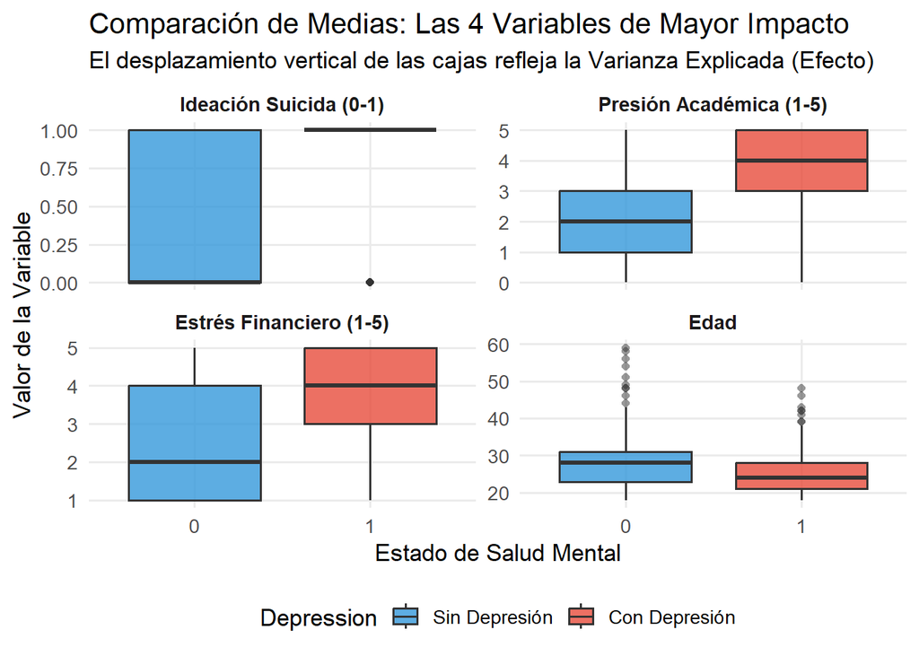

```r
# Preparamos los datos en formato largo para ggplot
data_anova_visual <- data_num %>%
  select(Depression, Suicidal_Num, Academic.Pressure, Financial.Stress, Age) %>%
  pivot_longer(cols = -Depression, names_to = "Variable", values_to = "Valor")

# Ajustamos los nombres para que se vean mejor en el gráfico
data_anova_visual$Variable <- factor(data_anova_visual$Variable,
                                     levels = c("Suicidal_Num", "Academic.Pressure", "Financial.Stress", "Age"),
                                     labels = c("Ideación Suicida (0-1)", "Presión Académica (1-5)",
                                                "Estrés Financiero (1-5)", "Edad"))

# Generamos el gráfico de cajas agrupado
ggplot(data_anova_visual, aes(x = Depression, y = Valor, fill = Depression)) +
  geom_boxplot(alpha = 0.8, outlier.shape = 16, outlier.alpha = 0.5) +
  facet_wrap(~Variable, scales = "free_y") +
  scale_fill_manual(values = c("0" = "#3498db", "1" = "#e74c3c"),
                    labels = c("Sin Depresión", "Con Depresión")) +
  labs(
    title = "Comparación de Medias: Las 4 Variables de Mayor Impacto",
    subtitle = "El desplazamiento vertical de las cajas refleja la Varianza Explicada (Efecto)",
    x = "Estado de Salud Mental",
    y = "Valor de la Variable"
  ) +
  theme_minimal(base_size = 13) +
  theme(
    legend.position = "bottom",
    strip.text = element_text(face = "bold", size = 11),
    panel.grid.minor = element_blank()
  )
```

### Presión Académica

Conclusión: Visualiza de forma limpia el efecto grande obtenido en el ANOVA ($\eta^2 = 0.23$). Aunque la presión académica es un mal común en la universidad, el gráfico demuestra que la población con depresión experimenta una concentración sistemática en los niveles de exigencia más severos e intolerables.

### Estrés Financiero

Detalle del Gráfico: Se observa un patrón muy similar al de la presión académica. La caja de los estudiantes con depresión se encuentra visiblemente desplazada hacia la parte alta de la escala de estrés económico, mientras que el grupo sin depresión abarca un rango más amplio hacia las puntuaciones bajas.

Conclusión: Este desfase representa el tamaño de efecto mediano-alto ($\eta^2 = 0.13$). La gráfica evidencia que la falta de recursos y la preocupación financiera actúan de forma constante como una barrera o un peso mayor en los estudiantes que cargan con un diagnóstico de depresión.